# HDAT9600 Final Team Assignment

Submission deadline - 03-May-2024

Team 3: Michelle Kim z5161954, Georgina Jacko z5441162, Harvey Lee z , Zhenyu Zhang z

2024-05-03

### Task 1 Part A: Exploratory data analysis

#### Step 1: Data Clean

- **Unique Patient Count:** There were 2061 and 2061unique patients contained in the dataset df0 and df1, confirming dataset consistency in terms of patient entries across both versions.
- **NaN or Infinite Values:**
  - *DF0*: There are variables with NaN or infinite values such as `Height`, `DiasABP_diff`, `SysABP_diff`, and others mainly associated with blood pressure and weight (146 for easch of `Weight_diff`, `Weight_max`, `Weight_min`). All of them has been Converted to NA.
  - *DF1*: No NaN or infinite values reported, which indicates either preprocessing steps were different or the issues were resolved in this version of the dataset.
- **Missing Values in df1:**
  - We set a **30%** threshold for maximum acceptable proportion of missing data in df1, and impute missing values for acceptable variables using median.
  - *High Missingness in Both Datasets*: Both datasets show significant numbers of missing values across various variables, particularly clinical measurements like `Albumin_diff`, `ALP_diff`, `Bilirubin_max`, and physiological parameters like `DiasABP_max`, `NIDiasABP_max`, etc.
  - `Height` (992, 48.13% missing) given the high rate of missing values, and low probability of importance to clinical outcome it has been excluded.
  - Blood pressure-related variables (`DiasABP_diff`, `DiasABP_max`, `DiasABP_min`, `NIDiasABP_diff`, `NIDiasABP_max`, `NIDiasABP_min`, `NIMAP_diff`, `NIMAP_max`, `NIMAP_min`, `NISysABP_diff`, `NISysABP_max`, `NISysABP_min`, `SysABP_diff`, `SysABP_max`, `SysABP_min`): All these have a high degree of missingness. Since these are many related variables with substantial missing data, we therefore considered only MAP, given the complete information.
  - *Survival Variable*: A crucial variable like `Survival` has a notably high count of missing values (1288), as it is the number of days between ICU admission and death for patients who died. Thus, no missing values impute for it.
  - *SAPS1*: `SAPS1` has 96 missing values (4.66% missing), which is a relatively small proportion of the dataset. Since SAPS-I is an important score for ICU prognosis, it might be worth imputing these values in df1 rather than excluding the variable.
  - *Weight-related variables* (`Weight_diff`, `Weight_max`, `Weight_min`): 146 missing values (7.08% missing) - Given this is a smaller proportion of missing data and weight is possibly an important variable for analysis it may be worth imputing values.
- **Variables to be excluded from df1 dataset due to high missing data:** DiasABP_diff, DiasABP_max, DiasABP_min, Height, SysABP_diff, SysABP_max, SysABP_min
- **Remaining total missing values in the cleaned df1 dataset:** There are SAPS1, SOFA, NIDiasABP_diff, NIDiasABP_max, NIDiasABP_min, NIMAP_diff, NIMAP_max, NIMAP_min, NISysABP_diff, NISysABP_max, NISysABP_min, Weight_diff, Weight_max, Weight_min with total 1288 missing values remaining. Given the complexity and breadth of clinical data, such a level of missingness can be considered manageable, particularly the missing values are spread across multiple variables rather than concentrated in a few.

#### Step 2: Exploratory data analysis

**Demographics**

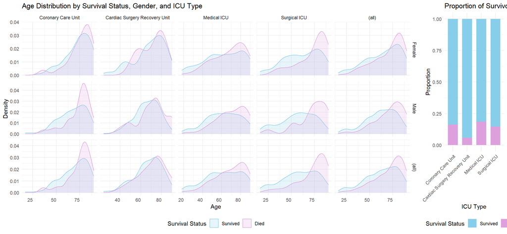

There were 2061 patients in total, with a higher proportion of males (approximately 55.70%) compared to females. - The proportion of patients who died in the hospital was about 14.41%. Patients range in age from 16 to 90, with a median age of 67, suggesting a predominantly older patient population.Survivors have a slightly lower mean age (63.29) compared to the overall (64.41) and non-survivor (71.05) groups. The distribution of patients across ICU types shows the largest number in the Medical ICU (38.23%) and the least in the Coronary Care Unit (14.41%). As Height has been excluded from both datasets and weight excluded from df0 due to high missing data, no more consideration.

Survival in a hospital ICU is influenced by numerous factors. Older age is often associated with a higher risk of death in an ICU, and this is supported by the plots showing a notable difference in the distribution of age for survivor and in hospital died patients. The plots shows very similar proportions of survivors/in-hospital deaths for each gender, suggesting it is also not a useful predictor, the plots for ICU type showed notably different proportions of survivors/in-hospital deaths per ICU type, with a significantly higher chance of survival in the cardiac surgery recovery unit, suggesting it may have some value as a predictor.

**Clinical measures**  
Clinical measures are critical in predicting ICU survival as they encapsulate various facets of a patient’s physiological state. In our dataset, we have segregated 36 clinical measures into different physiological systems for for fitting **Generalized Linear Models (GML)** to get the potential predictors for our model.  
- **Respiratory Function** is captured by PaO2, FiO2, and RespRate. - **Coagulation & Blood** metrics include Platelets, pH, and Glucose. - **Liver Function** is indicated by Bilirubin, Albumin, ALP, ALT, and AST. - **Cardiovascular System** measures comprise HR, MAP, TroponinI, TroponinT, and Lactate. - **Central Nervous System** is assessed primarily through GCS. - **Renal Function** involves Creatinine and Urine output. - **Immune System** response is gauged by Temperature and WBC counts.

Each clinical measures represented by up to three types of variables: the minimum (_min), the maximum (_max), and the difference (_diff) observed during the first 24 hours in the ICU. Furthermore, for variables like arterial blood pressure, both invasive and non-invasive measurements are taken into account, reflecting systolic, diastolic, and mean arterial pressures. Given the logistic regression’s sensitivity to multicollinearity, it is imperative to select the most representative variable among related measures to avoid high correlations that could skew model accuracy. Therefore, our analysis aims to discern not just the significance of each clinical measure in predicting ICU outcomes, but also to identify which among the related variables (minimum, maximum, or difference) most effectively captures the impact on survival. This approach helps in honing in on the most critical predictors and reduces redundancy in the model.

| Variable | Died Min | Died Q1 | Died Median | Died Q3 | Died Max | Survived Min.1 | Survived Q1.1 | Survived Median.1 | Survived Q3.1 | Survived Max.1 |
| --- | --- | --- | --- | --- | --- | --- | --- | --- | --- | --- |
| Age | 22 | 62 | 76 | 83 | 90 | 16 | 51 | 66 | 78 | 90 |
| SAPS1 | 3 | 14 | 18 | 21 | 33 | 1 | 11 | 15 | 18 | 34 |
| SOFA | 0 | 5 | 8 | 12 | 22 | 0 | 3 | 7 | 9 | 18 |
| Albumin_max | 1.1 | 2.5 | 2.8 | 3.3 | 4.5 | 1.4 | 2.7 | 3 | 3.5 | 5.3 |
| AST_max | 5 | 29 | 58 | 153 | 16040 | 5 | 26 | 50 | 127.25 | 9430 |
| Bilirubin_max | 0.1 | 0.4 | 0.8 | 1.7 | 45.9 | 0.1 | 0.4 | 0.7 | 1.2 | 41.9 |
| BUN_max | 4 | 20 | 33 | 55 | 172 | 3 | 13 | 19 | 29 | 197 |
| Creatinine_max | 0.3 | 0.9 | 1.4 | 2.4 | 12.2 | 0.2 | 0.7 | 1 | 1.4 | 22 |
| GCS_max | 3 | 8 | 11 | 15 | 15 | 3 | 11 | 15 | 15 | 15 |
| Glucose_max | 54 | 124 | 156 | 207 | 744 | 39 | 116 | 139 | 177 | 1143 |
| HCO3_max | 11 | 20 | 23 | 26 | 45 | 9 | 22 | 24 | 27 | 47 |
| HR_diff | 6.92210858958553 | 23.0778914104145 | 32.0778914104145 | 42.9221085895855 | 129.922108589586 | 0.922108589585534 | 20.0778914104145 | 27.0778914104145 | 35.9221085895855 | 212.922108589586 |
| Lactate_max | 0.4 | 1.6 | 2.3 | 3.8 | 29.3 | 0.5 | 1.5 | 2.1 | 3.2 | 15.9 |
| Na_diff | 0.206607094503113 | 2.20660709450311 | 4.20660709450311 | 7.20660709450311 | 31.7933929054969 | 0.206607094503113 | 1.79339290549689 | 3.20660709450311 | 5.20660709450311 | 41.2066070945031 |
| pH_diff | 0.000113764044943565 | 0.0601137640449432 | 0.0901137640449434 | 0.149886235955057 | 4.36988623595506 | 0.000113764044943565 | 0.0501137640449434 | 0.0801137640449436 | 0.120113764044944 | 0.509886235955056 |
| RespRate_max | 16 | 25 | 30 | 36 | 57 | 13 | 23 | 27 | 32 | 98 |
| Temp_diff | 0.325916935163519 | 0.925916935163521 | 1.32591693516352 | 1.82591693516352 | 12.7740830648365 | 0.125916935163524 | 0.874083064836476 | 1.22591693516353 | 1.72591693516353 | 5.17408306483648 |
| Urine_max | 0 | 120 | 240 | 420 | 4000 | 0 | 220 | 400 | 666.25 | 5000 |
| NISysABP_diff | 2.69874758010351 | 31.6987475801035 | 36.6987475801035 | 48.6987475801035 | 157.301252419896 | 0.301252419896485 | 27.3012524198965 | 34.3012524198965 | 40.3012524198965 | 134.301252419896 |

### Task 1 Part B: Predictive logistic model

By consider significance (`p-value`) and absolute `Estimate value` of predictors, we integrating following predictors and creating intact model strive to provide a holistic view of a patient’s health and potential survival odds in the ICU: 1. `Age` 2. `SAPS1` 3. `SOFA` 4. `Albumin_max` 5. `ALT_max` 6. `AST_max` 7. `Bilirubin_max` 8. `BUN_max` 9. `Cholesterol_max` 10. `Creatinine_max` 11. `GCS_max` 12. `GCS_min` 13. `Glucose_max` 14. `HR_diff` 15. `Lactate_max` 16. `Na_diff` 17. `NISysABP_diff` 18. `PaO2_max` 19. `pH_diff` 20. `pH_min` 21. `RespRate_max` 22. `Temp_diff` 23. `Urine_max` 24. `Urine_min` 25. `WBC_max` 26. `ICUType`

```r
# Creating intact model with all significant predictors
intact_model <- glm(in_hospital_death ~ Age + SAPS1 + SOFA + Albumin_max + ALT_max + AST_max + Bilirubin_max + BUN_max + Cholesterol_max +
                        Creatinine_max + GCS_max + GCS_min + Glucose_max + HR_diff + Lactate_max + Na_diff +
                        NISysABP_diff + PaO2_max + pH_diff + pH_min + RespRate_max + Temp_diff + Urine_max +
                        Urine_min + WBC_max + ICUType,
                    family = binomial(link = "logit"), data = icu_patients_df1_cleaned)
#summary(intact_model)
# Using stepwise regression to find an optimal set of predictors for intact model
stepwise_result <- stepAIC(intact_model, direction = "both", trace = FALSE) #stepwise_result2 <- stats::step(intact_model,direction="both", trace=0)
# Variance Inflation Factor (VIF) check
vif_values <- vif(stepwise_result, type = 'terms')
#print(vif_values)
summary(stepwise_result)
```

```
##
## Call:
## glm(formula = in_hospital_death ~ Age + SAPS1 + SOFA + Albumin_max +
##     ALT_max + AST_max + Bilirubin_max + BUN_max + Creatinine_max +
##     GCS_max + GCS_min + HR_diff + NISysABP_diff + PaO2_max +
##     pH_diff + Urine_max + ICUType, family = binomial(link = "logit"),
##     data = icu_patients_df1_cleaned)
##
## Coefficients:
##                                        Estimate Std. Error z value Pr(>|z|)
## (Intercept)                          -2.9586700  0.7516403  -3.936 8.28e-05 ***
## Age                                   0.0261907  0.0052084   5.029 4.94e-07 ***
## SAPS1                                 0.0580310  0.0230064   2.522 0.011656 *
## SOFA                                  0.0583371  0.0280534   2.079 0.037572 *
## Albumin_max                          -0.2497119  0.1199924  -2.081 0.037428 *
## ALT_max                              -0.0010521  0.0004431  -2.375 0.017571 *
## AST_max                               0.0007670  0.0002632   2.914 0.003570 **
## Bilirubin_max                         0.0463521  0.0135900   3.411 0.000648 ***
## BUN_max                               0.0154032  0.0037981   4.055 5.00e-05 ***
## Creatinine_max                       -0.1037505  0.0541855  -1.915 0.055527 .
## GCS_max                              -0.1708445  0.0275421  -6.203 5.54e-10 ***
## GCS_min                               0.0546851  0.0282780   1.934 0.053133 .
## HR_diff                               0.0078886  0.0043060   1.832 0.066948 .
## NISysABP_diff                         0.0075894  0.0039740   1.910 0.056160 .
## PaO2_max                             -0.0018209  0.0007904  -2.304 0.021244 *
## pH_diff                               2.5952276  1.1409727   2.275 0.022931 *
## Urine_max                            -0.0007388  0.0002126  -3.475 0.000511 ***
## ICUTypeCardiac Surgery Recovery Unit -0.7094156  0.3114644  -2.278 0.022746 *
## ICUTypeMedical ICU                   -0.0874038  0.2103697  -0.415 0.677793
## ICUTypeSurgical ICU                   0.0258841  0.2331446   0.111 0.911599
## ---
## Signif. codes:  0 '***' 0.001 '**' 0.01 '*' 0.05 '.' 0.1 ' ' 1
##
## (Dispersion parameter for binomial family taken to be 1)
##
##     Null deviance: 1699.7  on 2060  degrees of freedom
## Residual deviance: 1344.0  on 2041  degrees of freedom
## AIC: 1384
##
## Number of Fisher Scoring iterations: 6
```

#### Steps to Refine the Model:

- **stepAIC:**
  - method adds or removes predictors based on the AIC value in a stepwise manner to identify a model that balances model complexity with information loss. StepAIC() helped refine the model by retaining significant predictors and removing those less contributive variables.
  - The summary of the stepwise regression model presents similar significant variables and AIC as found in the previous model.
  - Predictors shows a relatively high p-value (>0.05),implies that it may not contribute meaningful explanatory power to the model in predicting in-hospital death.
- **VIF values:**
  - The VIF values common thresholds are 5 or 10, below that suggests that there isn’t a concerning level of multicollinearity among the main effects in the model.
  - High GVIF values for interaction terms are not uncommon, as these terms are products of their component variables and can inherit their collinearity.
  - High VIF/GVIF values do not imply that a model is invalid; rather, they suggest that the precision of the coefficient estimates for the related variables may be reduced.
- **Removing less important predictors:**
  - Drop Non-Significant (especially low abs of Estimate value) Predictors: `Glucose_max`, `Urine_min`, `Cholesterol_max`, `RespRate_max`
  - Address Multicollinearity: ``ALT_max` and `AST_max` both have high VIFs and are related liver enzymes, need redundancy.
  - Clinical Relevance: `GCS_min` (representing the lowest Glasgow Coma Score), despite its higher p-value, are clinically relevant and known to be associated with patient outcomes, need keep.

```r
# Then, our refined model is:
intact_model_rf <- glm(in_hospital_death ~ Age + SAPS1 + SOFA + Albumin_max  + ALT_max + AST_max + Bilirubin_max + BUN_max  + Creatinine_max + GCS_max + GCS_min + HR_diff + Lactate_max + Na_diff + NISysABP_diff + PaO2_max + pH_diff  + Temp_diff + Urine_max + WBC_max + ICUType, family = binomial(link = "logit"), data = icu_patients_df1_cleaned)
```

```r
# Comparing models with ANOVA
anova_results <- anova(intact_model, intact_model_rf, test = "Chisq")
print(anova_results)
```

```
## Analysis of Deviance Table
##
## Model 1: in_hospital_death ~ Age + SAPS1 + SOFA + Albumin_max + ALT_max +
##     AST_max + Bilirubin_max + BUN_max + Cholesterol_max + Creatinine_max +
##     GCS_max + GCS_min + Glucose_max + HR_diff + Lactate_max +
##     Na_diff + NISysABP_diff + PaO2_max + pH_diff + pH_min + RespRate_max +
##     Temp_diff + Urine_max + Urine_min + WBC_max + ICUType
## Model 2: in_hospital_death ~ Age + SAPS1 + SOFA + Albumin_max + ALT_max +
##     AST_max + Bilirubin_max + BUN_max + Creatinine_max + GCS_max +
##     GCS_min + HR_diff + Lactate_max + Na_diff + NISysABP_diff +
##     PaO2_max + pH_diff + Temp_diff + Urine_max + WBC_max + ICUType
##   Resid. Df Resid. Dev Df Deviance Pr(>Chi)
## 1      2032     1338.2
## 2      2037     1341.7 -5    -3.43    0.634
```

```r
# Creating two-way interaction models from previous models
two_way_model <- update(intact_model_rf, . ~ .^2)
# Dropping each two-way interaction term to test significance
drop_interaction_result <- drop1(two_way_model, test = "Chisq")
drop_interaction_result
```

[output not shown]

**Two-way interactions:** **1.** Most interaction terms do not significantly improve the model (indicated by high p-values), which implies that the main effects of the predictors are sufficient for the prediction. **2.** A few interaction terms do show significance (indicated by low p-values), which might suggest that the relationship between predictors and the in_hospital_death is more complex than additive. **3.** Notably: Considering the inclusion of interaction terms, it is essential to evaluate their clinical relevance and the potential for overfitting. Models with too many interactions, especially in smaller datasets, can fit the noise in the data rather than the underlying relationships, leading to models that may not generalize well to new data. *Inclusion of Main Effects*: Typically, when including an interaction term in a regression model, should also include the main effects of the interacting variables. This approach avoids the model misattributing the effects that should be captured by the main effects alone to the interaction term. `SOFA:pH_diff` (Pr(>Chi) = 2.912e-05) and `SOFA:WBC_max` (Pr(>Chi) = 0.000378) shown significant in two-way interaction model, they can be candidate predictors.

#### Re-fit Refined Model to the unimputed data frame df0

Before refitting the model, it’s important to acknowledge that several variables were excluded due to high levels of missing data. Proceeding with a direct refit results in a seemingly optimal AIC value of 229.87; however, this comes at the cost of losing 1819 observations. Such a reduction in the dataset size could impact the reliability and generalizability of the model.

**Model Refit Adjustments:**  
- Exclude variables (`Albumin_max`, `ALT_max`, `AST_max`, `Bilirubin_max`, `Lactate_max`, `NISysABP_diff`, `PaO2_max`, `pH_diff`) with high levels of missing data.  
- Can further exclude variables `Na_diff` (74 missing), `Urine_max` (70 missing) and `WBC_max`(76 missing).  
- Exclude less important variables.  
- Try include `Glucose_max` and `Urine_min`, which are viable predictors not significantly affected by missing data.  
- Try introduce interaction term `SOFA:WBC_max` to explore additional predictive relationships.

```
##
## Call:
## glm(formula = in_hospital_death ~ Age + SAPS1 + SOFA + BUN_max +
##     Creatinine_max + GCS_max + GCS_min + HR_diff + Urine_max +
##     ICUType, family = binomial(link = "logit"), data = icu_patients_df0_impute)
##
## Coefficients:
##                                        Estimate Std. Error z value Pr(>|z|)
## (Intercept)                          -3.8803602  0.6378783  -6.083 1.18e-09 ***
## Age                                   0.0211763  0.0051627   4.102 4.10e-05 ***
## SAPS1                                 0.0720861  0.0225430   3.198 0.001385 **
## SOFA                                  0.0959063  0.0275033   3.487 0.000488 ***
## BUN_max                               0.0183532  0.0040510   4.531 5.88e-06 ***
## Creatinine_max                       -0.1290924  0.0613355  -2.105 0.035318 *
## GCS_max                              -0.1690829  0.0276875  -6.107 1.02e-09 ***
## GCS_min                               0.0836136  0.0282872   2.956 0.003118 **
## HR_diff                               0.0071132  0.0043032   1.653 0.098335 .
## Urine_max                            -0.0007173  0.0002140  -3.352 0.000803 ***
## ICUTypeCardiac Surgery Recovery Unit -0.9460586  0.3031276  -3.121 0.001802 **
## ICUTypeMedical ICU                    0.0014586  0.2115710   0.007 0.994499
## ICUTypeSurgical ICU                   0.0233587  0.2342317   0.100 0.920563
## ---
## Signif. codes:  0 '***' 0.001 '**' 0.01 '*' 0.05 '.' 0.1 ' ' 1
##
## (Dispersion parameter for binomial family taken to be 1)
##
##     Null deviance: 1609.2  on 1941  degrees of freedom
## Residual deviance: 1296.5  on 1929  degrees of freedom
##   (因为不存在，119个观察量被删除了)
## AIC: 1322.5
##
## Number of Fisher Scoring iterations: 6
```

```
##                    GVIF Df GVIF^(1/(2*Df))
## Age            1.246316  1        1.116385
## SAPS1          2.305918  1        1.518525
## SOFA           2.425421  1        1.557376
## BUN_max        2.309878  1        1.519828
## Creatinine_max 2.175403  1        1.474925
## GCS_max        1.801511  1        1.342204
## GCS_min        3.290971  1        1.814103
## HR_diff        1.155935  1        1.075144
## Urine_max      1.136340  1        1.065993
## ICUType        1.424330  3        1.060723
```

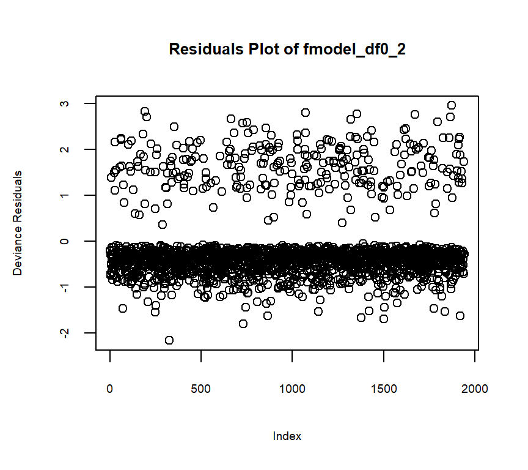

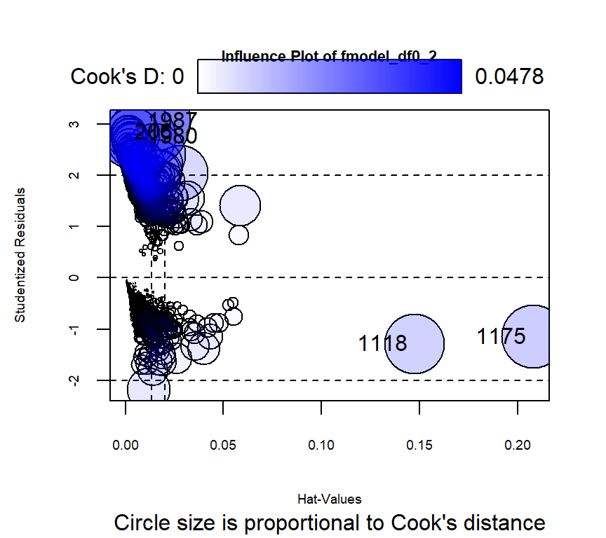

```
##        StudRes         Hat       CookD
## 206   2.842125 0.001170271 0.004871899
## 1118 -1.286021 0.147353090 0.016872382
## 1175 -1.142622 0.207781312 0.018912670
## 1980  2.758181 0.007815360 0.023011980
## 1987  3.061980 0.007768811 0.047825732
```

```
## Significant Values at or near Min/Max:
## Index 206, SOFA: 0.000000 near/at Min
## Index 206, GCS_max: 15.000000 near/at Max
## Index 206, GCS_min: 15.000000 near/at Max
## Index 206, Died in hospital
## Index 1118, GCS_min: 3.000000 near/at Min
## Index 1118, HR_diff: 212.922109 near/at Max
## Index 1118, Survivor
## Index 1175, BUN_max: 197.000000 near/at Max
## Index 1175, Creatinine_max: 22.000000 near/at Max
## Index 1175, GCS_min: 3.000000 near/at Min
## Index 1175, Survivor
```

After check influential_point 1175, we find that:  
- **BUN_max:**: Blood urea nitrogen measures the amount of nitrogen in the blood that comes from urea, a waste product processed by the kidneys, 197 is maximum in whole data.  
- **Creatinine_max:** A maximum creatinine level of 22 is maximum in whole data.  
- **GCS_min:** The minimum Glasgow Coma Scale (GCS) score of 3 is the lowest possible score, indicating severe brain injury or deep unconsciousness.  
- **Urine_min:** no volume of urine output.  
- **In-hospital death (0):** Despite severe kidney dysfunction, deep unconsciousness, and possible respiratory distress, the patient survived the hospital stay.This is kind of counterintuitive by consider the clinical parameters. It’s might be essential to review the medical records for such patients to understand the context better, validate the data accuracy, and decide on the inclusion in the analysis.

```
## Brier score for SAPS1 Model:  0.1217737
```

```
## Brier score for SOFA Model:  0.1214202
```

```
## Brier score for Final Model:  0.1054758
```

```
## Brier score for Final Model with interaction terms:  0.1057297
```

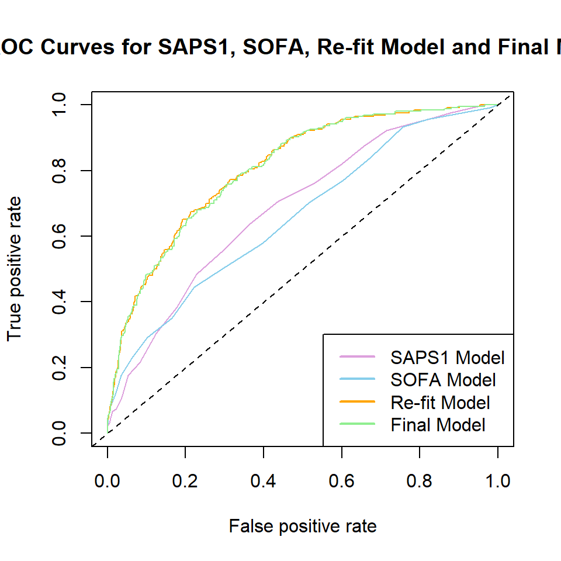

```
## AUC for SAPS1 Model: 0.6864565
```

```
## AUC for SOFA Model: 0.6591956
```

```
## AUC for Re-fit Model: 0.8085496
```

```
## AUC for Final Model: 0.8068159
```

### Task 2 Part A: Exploratory data analysis

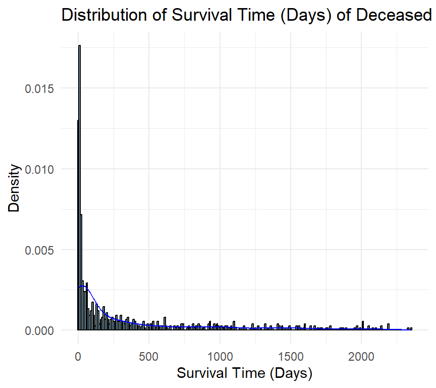

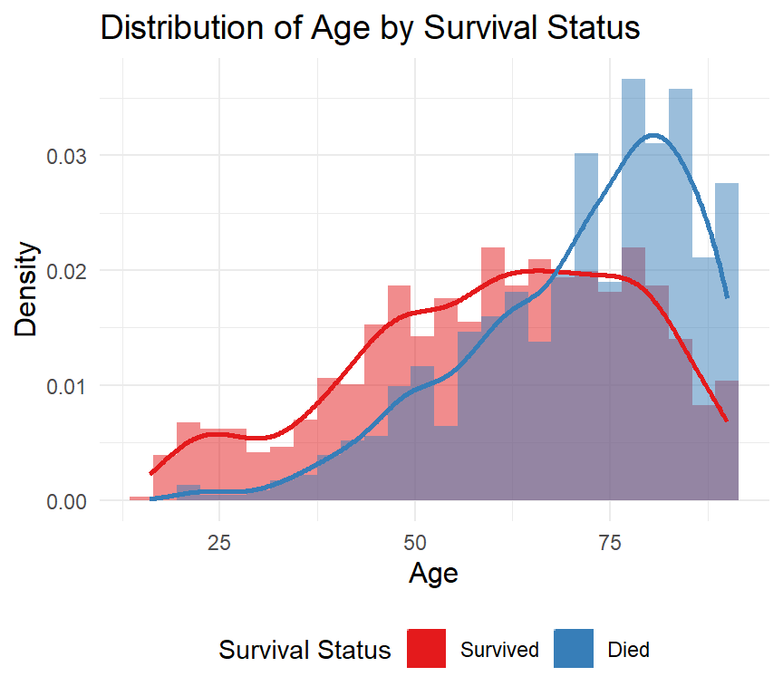

Survival Status of Patients

| Status | Frequency | Proportion |
| --- | --- | --- |
| Survived | 1288 | 62.49% |
| Deceased | 773 | 37.51% |

**Distribution of Survival Time (Days) of Deceased Patients**:  
- A heavy concentration of data at the lower end of the survival time spectrum, illustrateing that most deceased patients have a very short survival time post-admission. This indicates that many deaths occur relatively soon after hospital admission, which might reflect the severity of illness at the time of admission. It also underscores the urgency of effective early intervention in critical care settings, particularly for older patients.  
- If including values at 2408 days, the presence of a sharp peak at the far right end could indicate right-censoring at a study endpoint or a standard follow-up period.

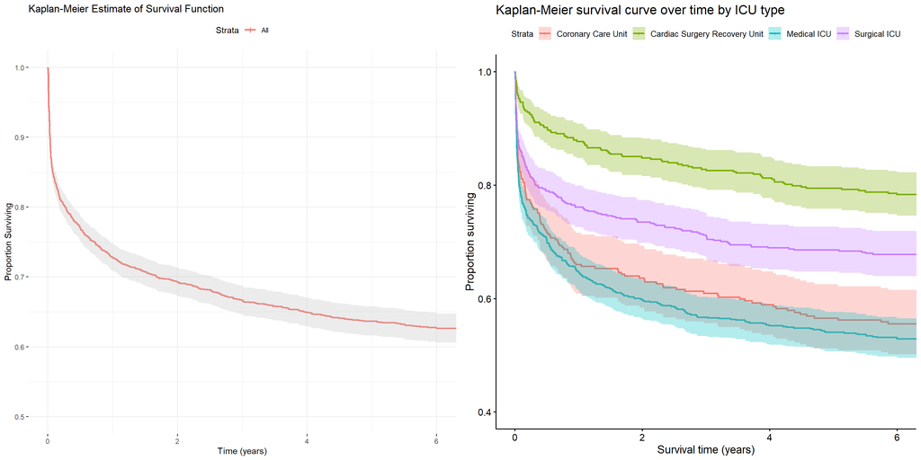

Mean (SD)

HR (univariable)

HR (multivariable)

15

SAPS1

15.0 (5.2)

1.07 (1.06-1.09, p<0.001)

1.03 (1.00-1.05, p=0.044)

16

SOFA

6.4 (4.2)

1.06 (1.05-1.08, p<0.001)

1.01 (0.98-1.04, p=0.596)

1

Albumin_max

3.0 (0.6)

0.82 (0.73-0.92, p<0.001)

0.90 (0.79-1.04, p=0.148)

2

AST_max

188.1 (765.8)

1.00 (1.00-1.00, p<0.001)

1.00 (1.00-1.00, p=0.041)

3

Bilirubin_max

1.7 (4.2)

1.03 (1.01-1.04, p=0.001)

1.02 (1.00-1.04, p=0.027)

4

BUN_max

27.5 (22.6)

1.02 (1.01-1.02, p<0.001)

1.01 (1.01-1.02, p<0.001)

5

Creatinine_max

1.5 (1.6)

1.11 (1.08-1.14, p<0.001)

0.93 (0.87-0.99, p=0.023)

6

GCS_max

12.9 (3.1)

0.92 (0.90-0.94, p<0.001)

0.94 (0.91-0.97, p<0.001)

7

Glucose_max

163.3 (88.5)

1.00 (1.00-1.00, p<0.001)

1.00 (1.00-1.00, p=0.520)

8

HCO3_max

24.3 (4.2)

0.98 (0.96-1.00, p=0.032)

1.01 (0.99-1.03, p=0.222)

9

HR_diff

30.4 (15.5)

1.01 (1.01-1.01, p<0.001)

1.00 (1.00-1.01, p=0.232)

10

Lactate_max

2.8 (2.2)

1.06 (1.03-1.09, p=0.001)

1.01 (0.97-1.06, p=0.570)

11

Na_diff

4.1 (3.7)

1.04 (1.03-1.06, p<0.001)

1.00 (0.98-1.02, p=0.934)

13

pH_diff

0.1 (0.1)

2.08 (1.51-2.86, p<0.001)

1.50 (0.89-2.52, p=0.130)

14

RespRate_max

29.1 (7.8)

1.01 (1.01-1.02, p=0.001)

1.00 (0.99-1.01, p=0.803)

18

Temp_diff

1.4 (0.8)

1.10 (1.01-1.21, p=0.034)

0.99 (0.88-1.10, p=0.817)

19

Urine_max

521.8 (508.5)

1.00 (1.00-1.00, p<0.001)

1.00 (1.00-1.00, p<0.001)

12

NISysABP_diff

37.8 (19.5)

1.01 (1.01-1.01, p<0.001)

1.00 (1.00-1.01, p=0.027)

17

### Task 2 Part B: Explanatory survival model

```r
# In data instraction "ICU stays of less than 48 hours have been excluded.", But I still see the 1 and 2 days value in `Days` variable.
#filtered_2days_data <- icu_patients_df1_cleaned %>% filter(Days >= 2)
cox_model_age <- coxph(Surv(Days, Status) ~ Age, data = icu_patients_df1_cleaned) # not sure if we should exclude < 2 days data as "ICU stays of less than 48 hours have been excluded." data = filtered_2days_data
summary(cox_model_age)
```

```
## Call:
## coxph(formula = Surv(Days, Status) ~ Age, data = icu_patients_df1_cleaned)
##
##   n= 2061, number of events= 773
##
##        coef exp(coef) se(coef)     z Pr(>|z|)
## Age 0.03355   1.03412  0.00250 13.42   <2e-16 ***
## ---
## Signif. codes:  0 '***' 0.001 '**' 0.01 '*' 0.05 '.' 0.1 ' ' 1
##
##     exp(coef) exp(-coef) lower .95 upper .95
## Age     1.034      0.967     1.029     1.039
##
## Concordance= 0.646  (se = 0.01 )
## Likelihood ratio test= 209.4  on 1 df,   p=<2e-16
## Wald test            = 180.1  on 1 df,   p=<2e-16
## Score (logrank) test = 187  on 1 df,   p=<2e-16
```

```
## Start:  AIC=10983.01
## Surv(Days, Status) ~ Age + SAPS1 + SOFA + BUN_max + Creatinine_max +
##     GCS_max + GCS_min + HR_diff + Urine_max + ICUType
##
##                  Df   AIC
## - HR_diff         1 10981
## <none>              10983
## - Creatinine_max  1 10983
## - Urine_max       1 10989
## - SOFA            1 10991
## - BUN_max         1 10999
## - GCS_min         1 11000
## - SAPS1           1 11001
## - GCS_max         1 11017
## - ICUType         3 11020
## - Age             1 11096
##
## Step:  AIC=10981.14
## Surv(Days, Status) ~ Age + SAPS1 + SOFA + BUN_max + Creatinine_max +
##     GCS_max + GCS_min + Urine_max + ICUType
##
##                  Df   AIC
## <none>              10981
## - Creatinine_max  1 10981
## + HR_diff         1 10983
## - Urine_max       1 10988
## - SOFA            1 10989
## - BUN_max         1 10997
## - GCS_min         1 10998
## - SAPS1           1 11002
## - GCS_max         1 11015
## - ICUType         3 11021
## - Age             1 11094
```

Summary of Stepwise Cox Model

|  | coef | exp(coef) | se(coef) | z | Pr(>\|z\|) |
| --- | --- | --- | --- | --- | --- |
| Age | 0.0274595 | 1.0278400 | 0.0026814 | 10.2406599 | 0.0000000 |
| SAPS1 | 0.0527927 | 1.0542111 | 0.0110645 | 4.7713630 | 0.0000018 |
| SOFA | 0.0468344 | 1.0479485 | 0.0145792 | 3.2124229 | 0.0013162 |
| BUN_max | 0.0082433 | 1.0082774 | 0.0018997 | 4.3393830 | 0.0000143 |
| Creatinine_max | -0.0385600 | 0.9621739 | 0.0269852 | -1.4289326 | 0.1530236 |
| GCS_max | -0.0882243 | 0.9155555 | 0.0146272 | -6.0315338 | 0.0000000 |
| GCS_min | 0.0601750 | 1.0620224 | 0.0140899 | 4.2707758 | 0.0000195 |
| Urine_max | -0.0002670 | 0.9997331 | 0.0000960 | -2.7813743 | 0.0054129 |
| ICUTypeCardiac Surgery Recovery Unit | -0.7530384 | 0.4709335 | 0.1477731 | -5.0959100 | 0.0000003 |
| ICUTypeMedical ICU | 0.0792308 | 1.0824541 | 0.1047697 | 0.7562377 | 0.4495067 |
| ICUTypeSurgical ICU | -0.1700844 | 0.8435936 | 0.1211985 | -1.4033541 | 0.1605113 |

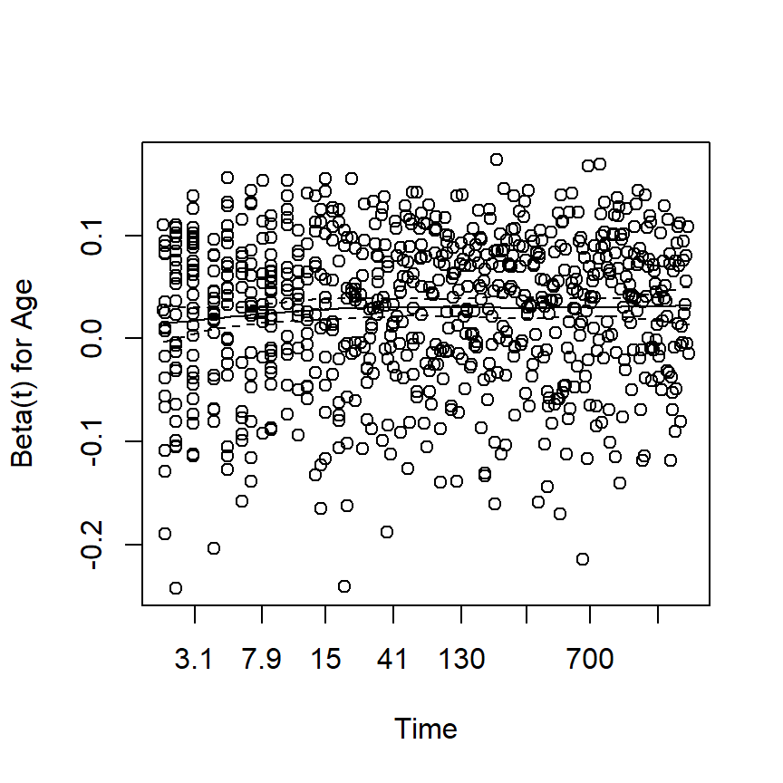

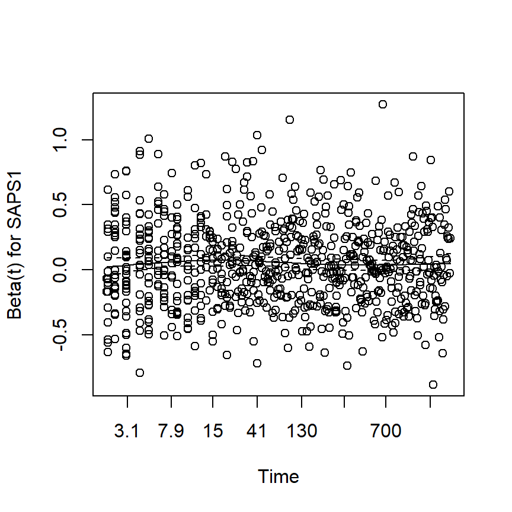

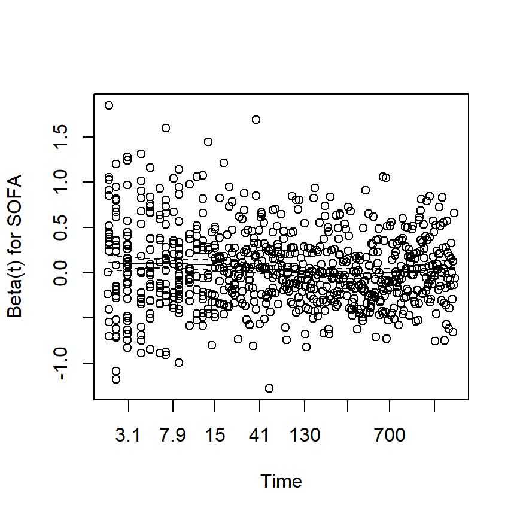

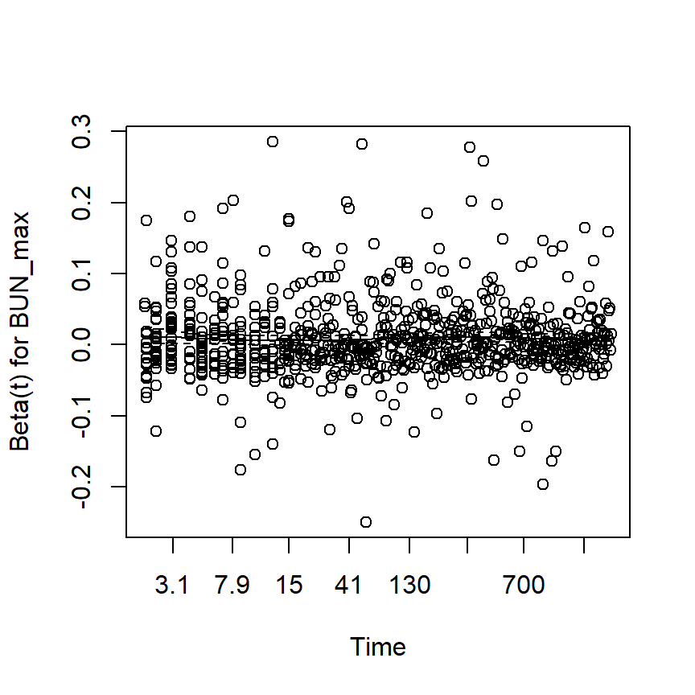

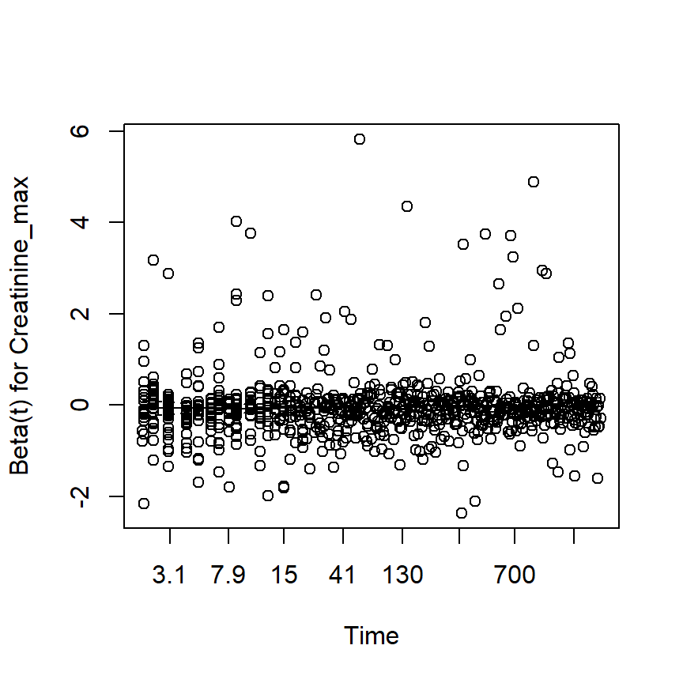

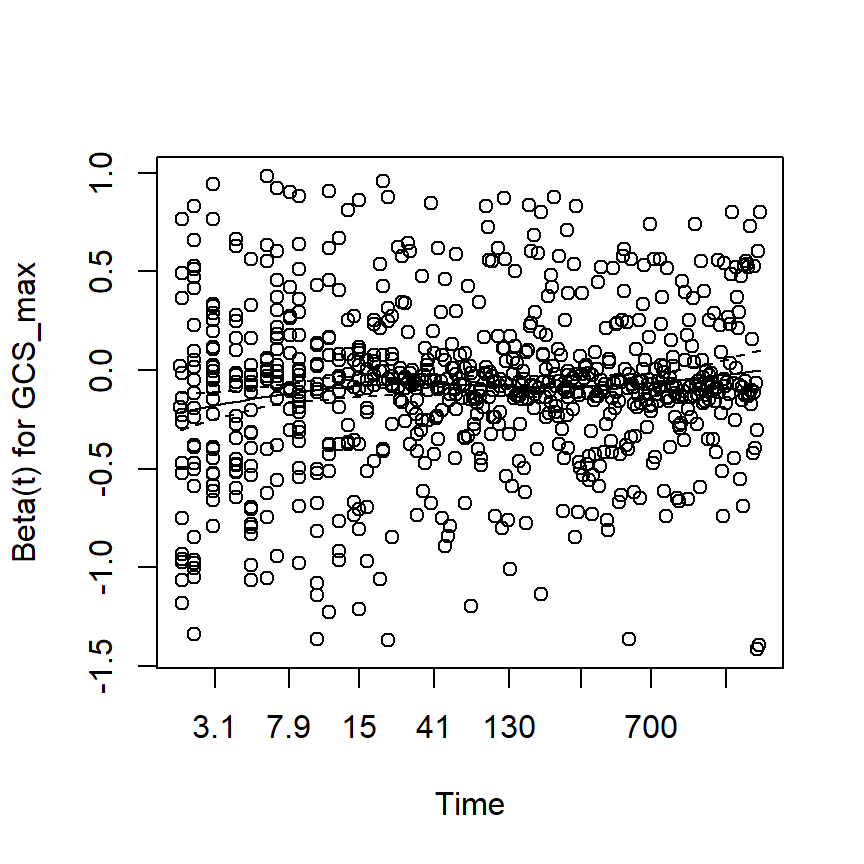

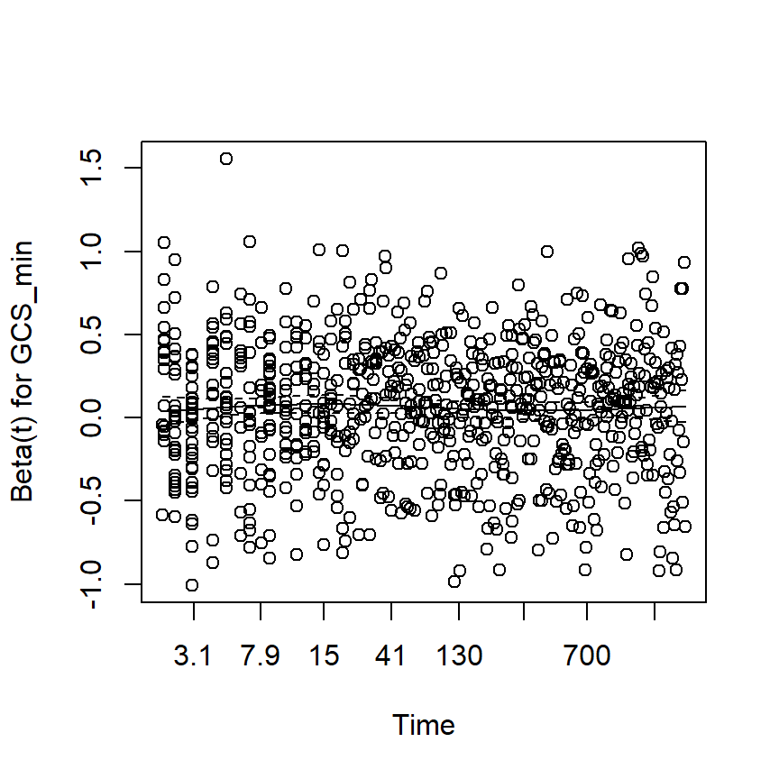

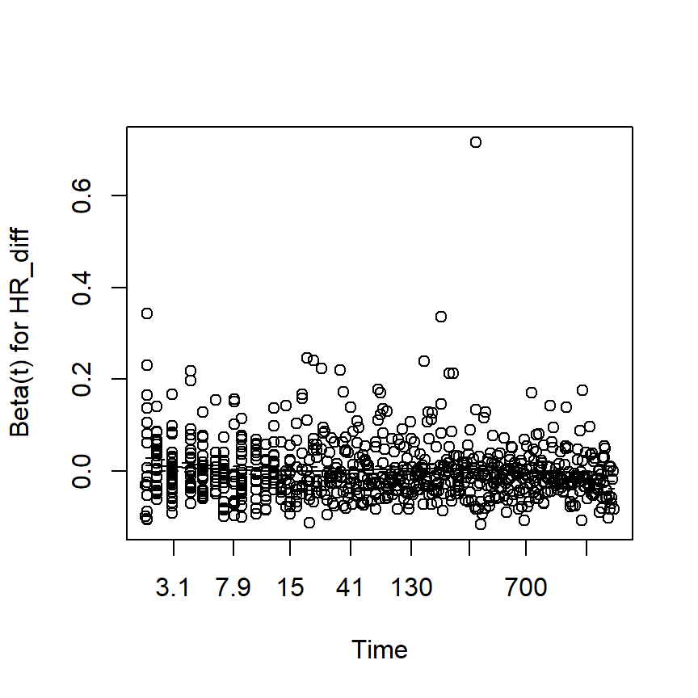